# Practical Machine Learning Course Project

# Amrit Juneja

## Executive Summary

This project utilizes data from accelerometers on the belt, forearm, arm, and dumbell of 6 participants who were asked to perform barbell lifts correctly and incorrectly in 5 different ways. It is an extension of sorts of the quantified self movement wherein the researchers have attempted to quantify how well a particular activity is performed rather than just how much of a particular activity. The data for this project come from this source: http://web.archive.org/web/20161224072740/http:/groupware.les.inf.puc-rio.br/har

## 1. Loading and Processing the Data

I have already downloaded the csv training and test data files and set the working directory to the folder containing those files

```r
train_in <- read.csv('./pml-training.csv', header=T)
valid_in <- read.csv('./pml-testing.csv', header=T)
dim(train_in)
```

```
## [1] 19622   160
```

```r
dim(valid_in)
```

```
## [1]  20 160
```

```r
head(train_in)
```

```
##   X user_name raw_timestamp_part_1 raw_timestamp_part_2   cvtd_timestamp
## 1 1  carlitos           1323084231               788290 05/12/2011 11:23
## 2 2  carlitos           1323084231               808298 05/12/2011 11:23
## 3 3  carlitos           1323084231               820366 05/12/2011 11:23
## 4 4  carlitos           1323084232               120339 05/12/2011 11:23
## 5 5  carlitos           1323084232               196328 05/12/2011 11:23
## 6 6  carlitos           1323084232               304277 05/12/2011 11:23
##   new_window num_window roll_belt pitch_belt yaw_belt total_accel_belt
## 1         no         11      1.41       8.07    -94.4                3
## 2         no         11      1.41       8.07    -94.4                3
## 3         no         11      1.42       8.07    -94.4                3
## 4         no         12      1.48       8.05    -94.4                3
## 5         no         12      1.48       8.07    -94.4                3
## 6         no         12      1.45       8.06    -94.4                3
##   kurtosis_roll_belt kurtosis_picth_belt kurtosis_yaw_belt
```

[output cut: 265 more lines]

## 2. Loading all the requisite libraries

```r
library(e1071)
library(caret)
```

```r
library(rpart)
library(rpart.plot)
library(RColorBrewer)
library(rattle)
library(randomForest)
library(corrplot)
library(gbm)
```

## 3. Cleaning the input training and test data sets

The data is cleaned in the following 3 steps: 1. Remove variables with missing (na) values 2. Remove the first seven variables as they do not have much impact on the outcome variable classe 3. Remove variables which have near zero variance (only applied on the training data set)

```r
trainData<- train_in[, colSums(is.na(train_in)) == 0]
validData <- valid_in[, colSums(is.na(valid_in)) == 0]
trainData <- trainData[, -c(1:7)]
validData <- validData[, -c(1:7)]
NZV <- nearZeroVar(trainData)
trainData <- trainData[, -NZV]
dim(trainData)
```

```
## [1] 19622    53
```

```r
dim(validData)
```

```
## [1] 20 53
```

## 4. Splitting the training data set for building prediction model

```r
set.seed(12345)
inTrain <- createDataPartition(trainData$classe, p = 0.75, list = FALSE)
trainData <- trainData[inTrain, ]
testData <- trainData[-inTrain, ]
dim(trainData)
```

```
## [1] 14718    53
```

```r
dim(testData)
```

```
## [1] 3683   53
```

## 5. Finding highly correlated variables

Before building the predictive model, variables which are highly correlated have been identified using a correlation plot on the training data set. In addition, variables with correlation of greater than 0.75 have been listed

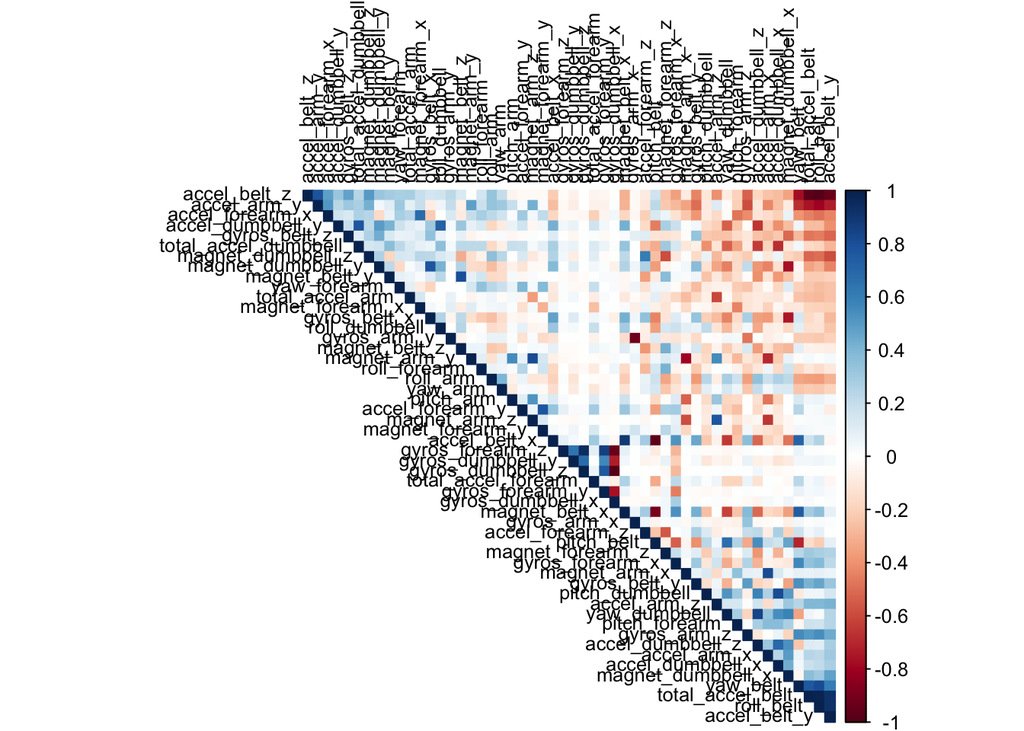

```r
cormatrix <- cor(trainData[, -53])
corrplot(cormatrix, order = "FPC", method = "color", type = "upper",
         tl.cex = 0.8, tl.col = rgb(0, 0, 0))
```

```r
highlyCorrelated = findCorrelation(cormatrix, cutoff=0.75)
names(trainData)[highlyCorrelated]
```

```
##  [1] "accel_belt_z"      "roll_belt"         "accel_belt_y"
##  [4] "total_accel_belt"  "accel_dumbbell_z"  "accel_belt_x"
##  [7] "pitch_belt"        "magnet_dumbbell_x" "accel_dumbbell_y"
## [10] "magnet_dumbbell_y" "accel_arm_x"       "accel_dumbbell_x"
## [13] "accel_arm_z"       "magnet_arm_y"      "magnet_belt_z"
## [16] "accel_forearm_y"   "gyros_forearm_y"   "gyros_dumbbell_x"
## [19] "gyros_dumbbell_z"  "gyros_arm_x"
```

## 6. Model Building

Three different algorithms have been used to arrive at the most suited prediction model: 1. Classification Trees 2. Random Forests 3. Generalized Boosted Model (GBM)

### 6.1 Classification Trees

Building the model and plotting the dendogram:

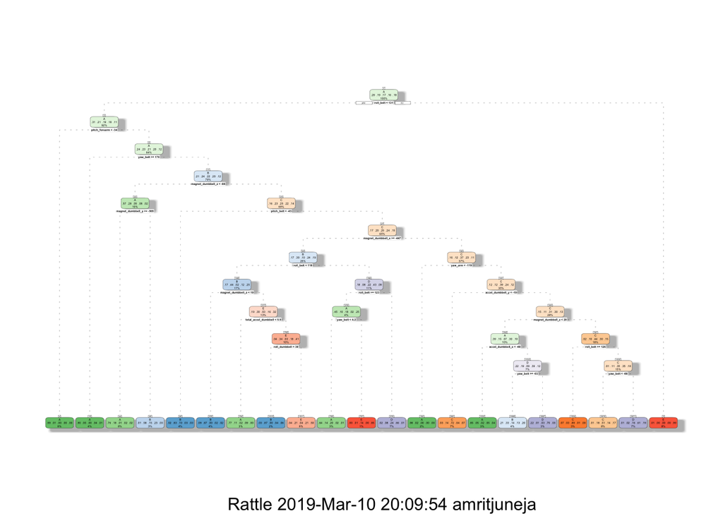

```r
set.seed(12345)
decisionTreeMod1 <- rpart(classe ~ ., data=trainData, method="class")
fancyRpartPlot(decisionTreeMod1)
```

Validating the model:

```r
predictTreeMod1 <- predict(decisionTreeMod1, testData, type = "class")
cmtree <- confusionMatrix(predictTreeMod1, testData$classe)
cmtree
```

```
## Confusion Matrix and Statistics
##
##           Reference
## Prediction   A   B   C   D   E
##          A 907  80  31  32  17
##          B  56 438  48  45  52
##          C  11 100 458  53  69
##          D  38  31 100 401  52
##          E  17  68  15  63 501
##
## Overall Statistics
##
##                Accuracy : 0.7345
##                  95% CI : (0.7199, 0.7487)
##     No Information Rate : 0.2794
##     P-Value [Acc > NIR] : < 2.2e-16
##
##                   Kappa : 0.6643
##  Mcnemar's Test P-Value : 1.705e-14
##
## Statistics by Class:
##
##                      Class: A Class: B Class: C Class: D Class: E
## Sensitivity            0.8814   0.6109   0.7025   0.6751   0.7250
## Specificity            0.9397   0.9322   0.9231   0.9285   0.9455
## Pos Pred Value         0.8500   0.6854   0.6628   0.6447   0.7545
## Neg Pred Value         0.9534   0.9083   0.9352   0.9369   0.9371
## Prevalence             0.2794   0.1947   0.1770   0.1613   0.1876
## Detection Rate         0.2463   0.1189   0.1244   0.1089   0.1360
## Detection Prevalence   0.2897   0.1735   0.1876   0.1689   0.1803
## Balanced Accuracy      0.9106   0.7716   0.8128   0.8018   0.8353
```

Checking accuracy by plotting the confusion matrix

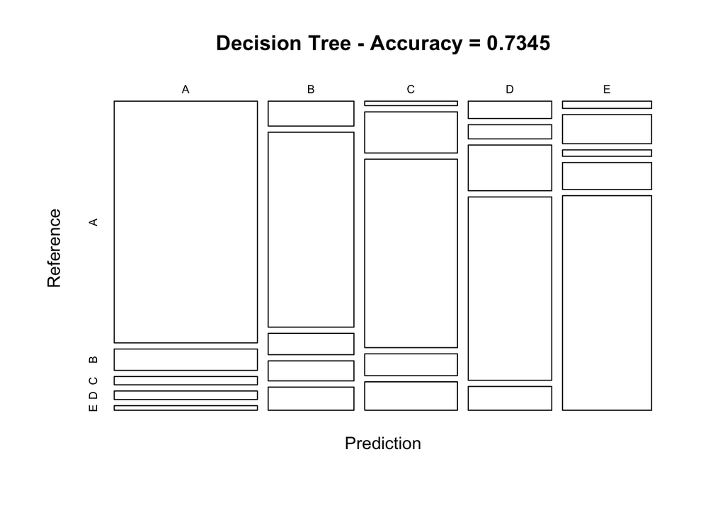

```r
plot(cmtree$table, col = cmtree$byClass,
     main = paste("Decision Tree - Accuracy =", round(cmtree$overall['Accuracy'], 4)))
```

The above plot shows that the accuracy at 0.7345 which is low and has a considerable out-of-sample error of ~27%

### 6.2 Random Forest

Building the model

```r
controlRF <- trainControl(method="cv", number=3, verboseIter=FALSE)
modRF1 <- train(classe ~ ., data=trainData, method="rf", trControl=controlRF)
modRF1$finalModel
```

```
##
## Call:
##  randomForest(x = x, y = y, mtry = param$mtry)
##                Type of random forest: classification
##                      Number of trees: 500
## No. of variables tried at each split: 27
##
##         OOB estimate of  error rate: 0.61%
## Confusion matrix:
##      A    B    C    D    E class.error
## A 4180    2    2    0    1 0.001194743
## B   17 2827    3    1    0 0.007373596
## C    0   10 2551    6    0 0.006232957
## D    0    1   29 2378    4 0.014096186
## E    0    1    3   10 2692 0.005173688
```

Validating the obtained RF model on Test Data and finding the accuracy

```r
predictRF1 <- predict(modRF1, newdata=testData)
cmrf <- confusionMatrix(predictRF1, testData$classe)
cmrf
```

```
## Confusion Matrix and Statistics
##
##           Reference
## Prediction    A    B    C    D    E
##          A 1029    0    0    0    0
##          B    0  717    0    0    0
##          C    0    0  652    0    0
##          D    0    0    0  594    0
##          E    0    0    0    0  691
##
## Overall Statistics
##
##                Accuracy : 1
##                  95% CI : (0.999, 1)
##     No Information Rate : 0.2794
##     P-Value [Acc > NIR] : < 2.2e-16
##
##                   Kappa : 1
##  Mcnemar's Test P-Value : NA
##
## Statistics by Class:
##
##                      Class: A Class: B Class: C Class: D Class: E
## Sensitivity            1.0000   1.0000    1.000   1.0000   1.0000
## Specificity            1.0000   1.0000    1.000   1.0000   1.0000
## Pos Pred Value         1.0000   1.0000    1.000   1.0000   1.0000
## Neg Pred Value         1.0000   1.0000    1.000   1.0000   1.0000
## Prevalence             0.2794   0.1947    0.177   0.1613   0.1876
## Detection Rate         0.2794   0.1947    0.177   0.1613   0.1876
## Detection Prevalence   0.2794   0.1947    0.177   0.1613   0.1876
## Balanced Accuracy      1.0000   1.0000    1.000   1.0000   1.0000
```

The accuracy rate of 1 is very high implying an out of sample error of 0. However, this may be due to overfitting as well.

Plotting the model

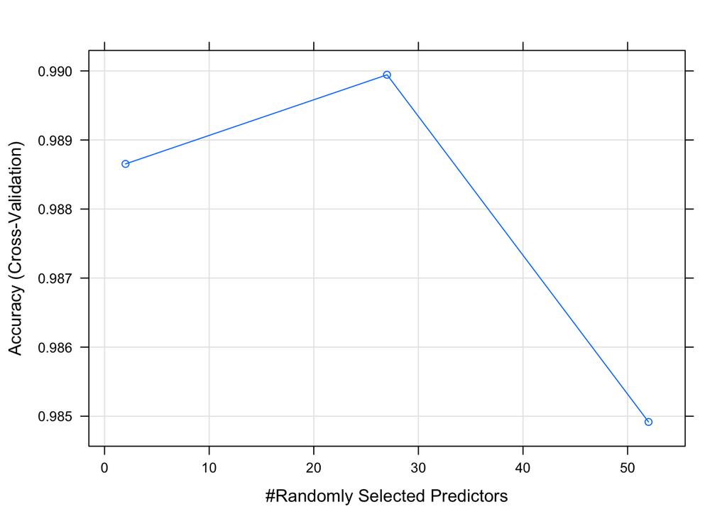

```r
plot(modRF1)
```

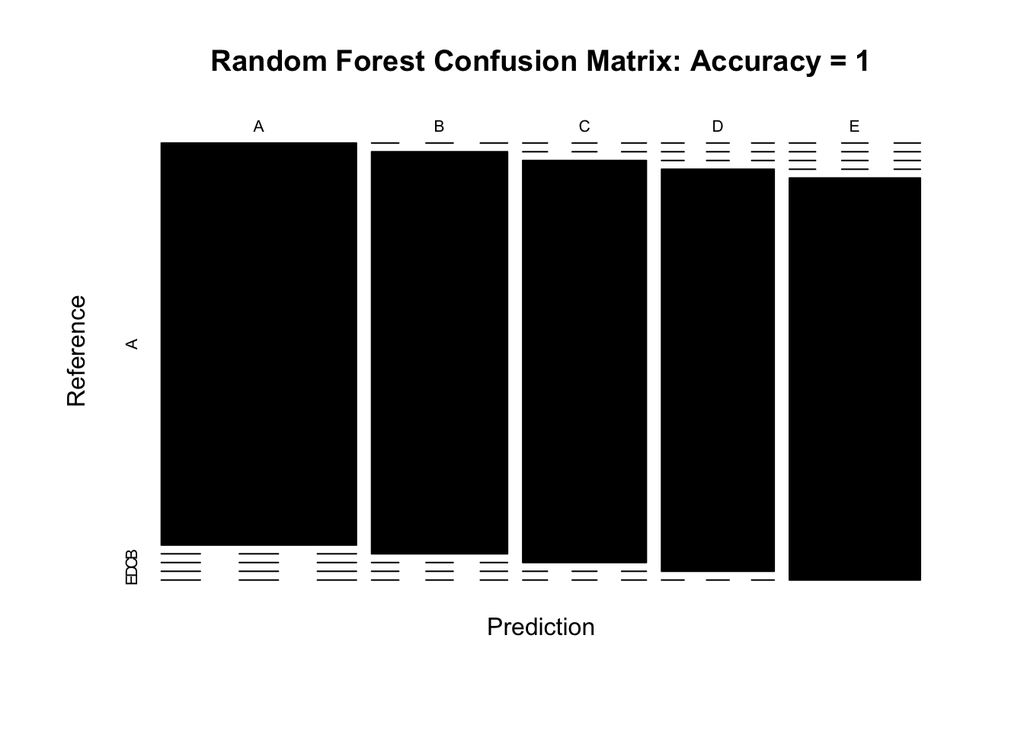

```r
plot(cmrf$table, col = cmrf$byClass, main = paste("Random Forest Confusion Matrix: Accuracy =", round(cmrf$overall['Accuracy'], 4)))
```

### 6.3 Generalized Boosted Regression Model

Building the model

```r
set.seed(12345)
controlGBM <- trainControl(method = "repeatedcv", number = 5, repeats = 1)
modGBM  <- train(classe ~ ., data=trainData, method = "gbm", trControl = controlGBM, verbose = FALSE)
modGBM$finalModel
```

```
## A gradient boosted model with multinomial loss function.
## 150 iterations were performed.
## There were 52 predictors of which 52 had non-zero influence.
```

```r
print(modGBM)
```

```
## Stochastic Gradient Boosting
##
## 14718 samples
##    52 predictor
##     5 classes: 'A', 'B', 'C', 'D', 'E'
##
## No pre-processing
## Resampling: Cross-Validated (5 fold, repeated 1 times)
## Summary of sample sizes: 11774, 11774, 11774, 11775, 11775
## Resampling results across tuning parameters:
##
##   interaction.depth  n.trees  Accuracy   Kappa
##   1                   50      0.7564204  0.6912841
##   1                  100      0.8198803  0.7719731
##   1                  150      0.8549392  0.8164228
##   2                   50      0.8548710  0.8160546
##   2                  100      0.9069841  0.8822549
##   2                  150      0.9315804  0.9134034
##   3                   50      0.8951620  0.8672751
##   3                  100      0.9428588  0.9277012
##   3                  150      0.9610000  0.9506585
##
## Tuning parameter 'shrinkage' was held constant at a value of 0.1
##
## Tuning parameter 'n.minobsinnode' was held constant at a value of 10
## Accuracy was used to select the optimal model using the largest value.
## The final values used for the model were n.trees = 150,
##  interaction.depth = 3, shrinkage = 0.1 and n.minobsinnode = 10.
```

Validating the model on the test data and determining accuracy

```r
predictGBM <- predict(modGBM, newdata=testData)
cmGBM <- confusionMatrix(predictGBM, testData$classe)
cmGBM
```

```
## Confusion Matrix and Statistics
##
##           Reference
## Prediction    A    B    C    D    E
##          A 1020   19    0    0    0
##          B    7  689    9    3    4
##          C    1    9  639   16    2
##          D    1    0    4  575    7
##          E    0    0    0    0  678
##
## Overall Statistics
##
##                Accuracy : 0.9777
##                  95% CI : (0.9724, 0.9823)
##     No Information Rate : 0.2794
##     P-Value [Acc > NIR] : < 2.2e-16
##
##                   Kappa : 0.9719
##  Mcnemar's Test P-Value : NA
##
## Statistics by Class:
##
##                      Class: A Class: B Class: C Class: D Class: E
## Sensitivity            0.9913   0.9609   0.9801   0.9680   0.9812
## Specificity            0.9928   0.9922   0.9908   0.9961   1.0000
## Pos Pred Value         0.9817   0.9677   0.9580   0.9796   1.0000
## Neg Pred Value         0.9966   0.9906   0.9957   0.9939   0.9957
## Prevalence             0.2794   0.1947   0.1770   0.1613   0.1876
## Detection Rate         0.2769   0.1871   0.1735   0.1561   0.1841
## Detection Prevalence   0.2821   0.1933   0.1811   0.1594   0.1841
## Balanced Accuracy      0.9920   0.9766   0.9854   0.9821   0.9906
```

The accuracy for this model is also very high at 0.9777 implying an out of sample error of .0223

## 7. Application of Final Model on Validation Data (Original test data set of 20 cases)

On the basis of accuracy rates, random forest model (6.2) is the best-suited model for prediction of classe variable in the dataset

```r
Results <- predict(modRF1, newdata=validData)
Results
```

```
##  [1] B A B A A E D B A A B C B A E E A B B B
## Levels: A B C D E
```